# R Notebook

# Original Experiment

## Question

Markov was addressing a precise mathematical curiosity.

> Do the laws of probability, such as the Law of Large Numbers, require **independent events**, or can they hold even when events are dependent?

He wanted to demonstrate a counterexample: a dependent sequence where statistical regularities still emerge.

- Independence: $P(X_{t+1} | X_t, X_{t-1},...) = P(X_{t+1})$
- Markov property (dependence only on the present): $P(X_{t+1} | X_t, X_{t-1},...) = P(X_{t+1} | X_t)$

The key insight: first-order dependence is enough to preserve stable frequencies over the long run.

## Model

Markov chose letters in text to demonstrate the counterexample because:

- They are finite and discrete,
- Long sequences are available, and
- Dependencies exist (letters influence the next letter), but the system is simple.

He made deliberate simplifications:

- Ignore punctuation, which is not essential to the probability claim,
- Ignore spaces to treat text as a continuous stream,
- Ignore case and treat all letters in terms of state, and
- Focus on single-letter transitions, i.e. first-order chain.

The object of the study became state space: {a, b, c, …, z} with transitions (each letter to next letter) with a long sequence of letters.

## Data Collection

Markov literally counted transitions, which was a manual effort in his time, where every letter is a current state, every next letter is a next state, and overlapping pairs are counted.

| From | To | Count |
| --- | --- | --- |
| a | a | … |
| a | b | … |
| … | … | … |

From these counts, he built a transition matrix $P$:
$$P_{ij} = \frac{\text{Number of transitions from letter i to letter
j}}{\text{Number of times letter i occurs as 'from'}}$$

## Observations

Even though the letters were dependent, the process was not independent. The empirical frequencies of letters converged and matched theoretical predictions from the transition matrix.

This demonstrated that statistical regularity can arise under dependence.

# My Experiment: Letter Transitions in Joyce

## Load Libraries

```r
library("dplyr")
library("ggplot2")
library("igraph")
library("reshape2")
```

## Source Text

I use a passage from James Joyce, *The Sisters*, as the sequence of letters:

> There was no hope for him this time: it was the third stroke. Night after night I had passed the house (it was vacation time) and studied the lighted square of window: and night after night I had found it lighted in the same way, faintly and evenly. If he was dead, I thought, I would see the reflection of candles on the darkened blind for I knew that two candles must be set at the head of a corpse. He had often said to me: I am not long for this world, and I had thought his words idle.

## Read and Clean Text

I remove punctuation and spaces to replicate Markov’s original method. All letters are converted to lowercase, and the cleaned text becomes a single, continuous string of letters. For this excerpt, `n_chars` should be 378 letters.

```r
# Read the text from a file
text_raw <- readLines("../inst/extdata/joyce_excerpt.txt", warn = FALSE)
text_raw <- paste(text_raw, collapse = "")

# Clean text: remove punctuation, spaces; convert to lowercase
text_clean <- gsub("[^A-Za-z]", "", text_raw)
text_clean <- tolower(text_clean)

# Split into individual characters
chars <- strsplit(text_clean, "")[[1]]

# Confirm number of characters
n_chars <- length(chars)
n_chars
```

[output not shown]

## Generate Overlapping Transitions

```r
# Overlapping pairs: current letter -> next letter
from <- chars[-length(chars)]  # all letters except the last
to   <- chars[-1]              # all letters except the first

# Combine into a data frame
transitions <- data.frame(from = from,
                          to   = to,
                          stringsAsFactors = FALSE)

# Preview first 10 transitions
head(transitions, 10)
```

[output not shown]

`from = chars[-length(chars)]` excludes the last character, which cannot transition to anything.

`to = chars[-1]` excludes the first character, aligning each element to the next state.

Together, each row represents a single transition, exactly as Markov’s method.

## Build the Transition Matrix

```r
# Count occurrences for each letter pair
tab <- table(transitions$from, transitions$to)

# Optional: show a small subset of the table
tab[letters[1:5], letters[1:5]]
```

[output not shown]

`table()` counts all observed transition from `from` to `to`. This is the empirical basis for a first-order Markov chain. Row normalization of this table produces transition probabilities, allowing computation of long-run letter frequencies.

## Build the Transition Matrix

Using the transitions data frame, count occurrences and normalize rows.

```r
# Count occurrences
tab <- table(transitions$from, transitions$to)

# Convert to numeric matrix
P <- prop.table(tab, margin = 1)  # row-normalize to get probabilities

# Preview first 5 rows and columns
P[letters[1:5], letters[1:5]]
```

[output not shown]

`prop.table(..., margin = 1)` normalizes each row so that all probabilities sum to one. Each row `i` corresponds to the current letter; each column `j` corresponds to the probability of transitioning to `j`. This is the first-order Markkov chain transition matrix.

## Compute the Stationary Distribution

The stationary distribution $\pi$ solves $\pi P = \pi$. In R, we can compute it via eigenvectors or iteration. Either method gives $\pi$, the long-run probabilities of each letter.

### Option A: Eigenvector Method

```r
eig <- eigen(t(P))  # transpose because eigen solves vP = v

pi <- Re(eig$vectors[,1])

pi <- pi / sum(pi)  # normalize

names(pi) <- rownames(P)

pi[1:10]  # preview first 10 letters
```

[output not shown]

### Option B: Iterative Method (Convergence)

```r
# All letters.

letters_all <- letters

# Initialize empty matrix.

P_full <- matrix(0, nrow = 26, ncol = 26,
                 dimnames = list(letters_all, letters_all))

# Fill in observed probabilities.

observed_letters <- rownames(P)

P_full[observed_letters, observed_letters] <- P

# Check dimensions.

dim(P_full)
```

## Iterative Stationary Distribution

```r
# Start with uniform distribution.

pi_iter <- rep(1/26, 26)

# Iteratively converge.

for(i in 1:1000) {
    pi_iter <- pi_iter %*% P_full
}

# Normalize

pi_iter <- as.vector(pi_iter)

names(pi_iter) <- letters_all

# Preview.

pi_iter[1:10]
```

[output not shown]

## Compare Empirical Letter Frequencies

```r
# Count letters in cleaned text.

empirical <- table(chars) / length(chars)

# Make sure to include missing letters.

empirical_full <- setNames(rep(0, 26), letters_all)

empirical_full[names(empirical)] <- empirical

# Comparison

compare <- data.frame(letter = letters_all,
                      empirical = as.numeric(empirical_full),
                      stationary = pi_iter)

compare
```

[output not shown]

## Visualize Transition Probabilities

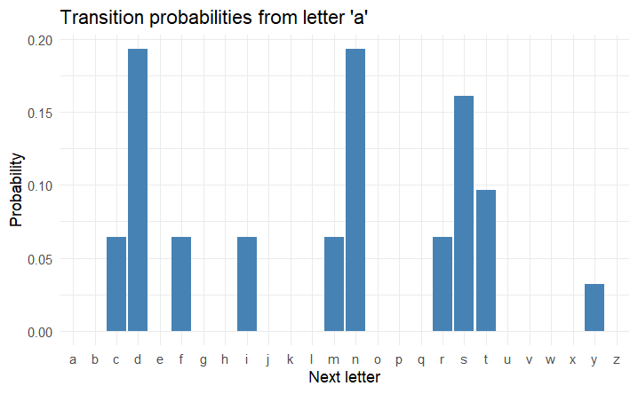

```r
# Melt full transition matrix.

P_long <- melt(P_full)

colnames(P_long) <- c("from", "to", "prob")

# Bar plot: transitions from letter 't'.

ggplot(subset(P_long, from == "a"), aes(x = to, y = prob)) +
  geom_bar(stat = "identity", fill = "steelblue") +
  labs(title = "Transition probabilities from letter 'a'",
       x = "Next letter",
       y = "Probability") +
  theme_minimal()
```

## Network Visual

Convert the matrix to an edge list.

```r
# Convert matrix to long format.

P_long <- melt(P_full)

colnames(P_long) <- c("from", "to", "prob")

# Remove zero-probability transitions.

P_long <- subset(P_long, prob > 0)
```

Top n transitions per letter.

```r
edges <- P_long %>%
  group_by(from) %>%
  slice_max(prob, n = 2) %>%
  ungroup()
```

Build and plot the Markov network.

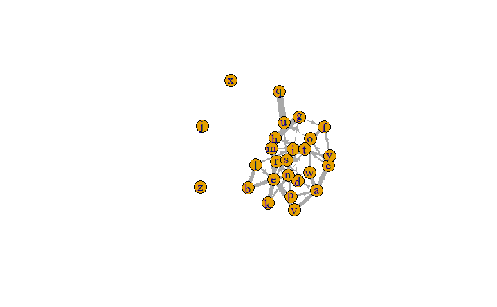

```r
g <- graph_from_data_frame(
  edges,
  directed = TRUE,
  vertices = data.frame(name = letters)
)

set.seed(123)

layout <- layout_with_kk(g)

plot(
  g,
  layout = layout,
  vertex.size = 20,
  vertex.label.cex = 0.9,
  edge.width = edges$prob * 8,
  edge.arrow.size = 0.4
)
```

What this shows

Nodes = letters

Directed edges = transition probabilities

Edge thickness = strength of transition

Clusters = letters that frequently follow one another

You’ll notice:

Strong vowel–consonant patterns

Structural asymmetries (q → u almost always)

This is the Markov structure made visible.

## Circular Layout

```r
library(ggraph)


ggraph(g, layout = "circle") +
  geom_edge_arc(
    aes(width = prob),
    alpha = 0.7,
    strength = 0.7
  ) +
  geom_node_point(aes(size = pi)) +
  geom_node_text(aes(label = name), vjust = 1.8) +
  scale_edge_width(range = c(0.2, 3)) +
  scale_size(range = c(4, 16)) +
  theme_void()
```

[output not shown]